# SVMs

## SVMs for Classification

```python
import pandas as pd
import numpy as np
from sklearn.model_selection import train_test_split
from sklearn.metrics import mean_squared_error as MSE
import matplotlib.pyplot as plt
from sklearn.preprocessing import StandardScaler
from sklearn.metrics import roc_auc_score
from sklearn.metrics import roc_curve
```

Here we use the OJ dataset. The data contains 1070 purchases where the customer either purchased Citrus Hill or Minute Maid Orange Juice. A number of characteristics of the customer and product are recorded.

```python
OJ=pd.read_csv('OJ.csv',index_col=0)
OJ.head()
```

|  | Purchase | WeekofPurchase | StoreID | PriceCH | PriceMM | DiscCH | DiscMM | SpecialCH | SpecialMM | LoyalCH | SalePriceMM | SalePriceCH | PriceDiff | Store7 | PctDiscMM | PctDiscCH | ListPriceDiff | STORE |
| --- | --- | --- | --- | --- | --- | --- | --- | --- | --- | --- | --- | --- | --- | --- | --- | --- | --- | --- |
| 1 | CH | 237 | 1 | 1.75 | 1.99 | 0.00 | 0.0 | 0 | 0 | 0.500000 | 1.99 | 1.75 | 0.24 | No | 0.000000 | 0.000000 | 0.24 | 1 |
| 2 | CH | 239 | 1 | 1.75 | 1.99 | 0.00 | 0.3 | 0 | 1 | 0.600000 | 1.69 | 1.75 | -0.06 | No | 0.150754 | 0.000000 | 0.24 | 1 |
| 3 | CH | 245 | 1 | 1.86 | 2.09 | 0.17 | 0.0 | 0 | 0 | 0.680000 | 2.09 | 1.69 | 0.40 | No | 0.000000 | 0.091398 | 0.23 | 1 |
| 4 | MM | 227 | 1 | 1.69 | 1.69 | 0.00 | 0.0 | 0 | 0 | 0.400000 | 1.69 | 1.69 | 0.00 | No | 0.000000 | 0.000000 | 0.00 | 1 |
| 5 | CH | 228 | 7 | 1.69 | 1.69 | 0.00 | 0.0 | 0 | 0 | 0.956535 | 1.69 | 1.69 | 0.00 | Yes | 0.000000 | 0.000000 | 0.00 | 0 |

```python
OJ.WeekofPurchase.unique()
```

```
array([237, 239, 245, 227, 228, 230, 232, 234, 235, 238, 240, 263, 276,
       268, 278, 269, 254, 257, 258, 259, 264, 271, 272, 274, 246, 265,
       275, 251, 256, 277, 229, 233, 236, 244, 247, 248, 249, 252, 260,
       266, 267, 270, 255, 273, 242, 241, 243, 253, 261, 231, 250, 262])
```

```python
OJ.StoreID.unique()
```

```
array([1, 7, 2, 3, 4])
```

```python
OJ.STORE.unique()
```

```
array([1, 0, 2, 3, 4])
```

Therefore, StoreID and STORE should be categorical variables, but in the dataset it is numerical. We should transform it to categorical variables and use one-hot encoding to get the feature values.

```python
OJ.StoreID = OJ.StoreID.astype('category')
```

Here we skip 'WeekofPurchase' and 'STORE' variables since "STORE" might be correlated with "StoreID" and 'WeekofPurchase' contains too many levels. For different dataset, you can use different methods to deal with categorical variables.

```python
OJX = pd.get_dummies(OJ.drop(['Purchase','WeekofPurchase','STORE','Store7'], axis=1))
OJX.head()
```

|  | PriceCH | PriceMM | DiscCH | DiscMM | SpecialCH | SpecialMM | LoyalCH | SalePriceMM | SalePriceCH | PriceDiff | PctDiscMM | PctDiscCH | ListPriceDiff | StoreID_1 | StoreID_2 | StoreID_3 | StoreID_4 | StoreID_7 |
| --- | --- | --- | --- | --- | --- | --- | --- | --- | --- | --- | --- | --- | --- | --- | --- | --- | --- | --- |
| 1 | 1.75 | 1.99 | 0.00 | 0.0 | 0 | 0 | 0.500000 | 1.99 | 1.75 | 0.24 | 0.000000 | 0.000000 | 0.24 | 1 | 0 | 0 | 0 | 0 |
| 2 | 1.75 | 1.99 | 0.00 | 0.3 | 0 | 1 | 0.600000 | 1.69 | 1.75 | -0.06 | 0.150754 | 0.000000 | 0.24 | 1 | 0 | 0 | 0 | 0 |
| 3 | 1.86 | 2.09 | 0.17 | 0.0 | 0 | 0 | 0.680000 | 2.09 | 1.69 | 0.40 | 0.000000 | 0.091398 | 0.23 | 1 | 0 | 0 | 0 | 0 |
| 4 | 1.69 | 1.69 | 0.00 | 0.0 | 0 | 0 | 0.400000 | 1.69 | 1.69 | 0.00 | 0.000000 | 0.000000 | 0.00 | 1 | 0 | 0 | 0 | 0 |
| 5 | 1.69 | 1.69 | 0.00 | 0.0 | 0 | 0 | 0.956535 | 1.69 | 1.69 | 0.00 | 0.000000 | 0.000000 | 0.00 | 0 | 0 | 0 | 0 | 1 |

```python
ss=StandardScaler(with_mean=False)
OJX= ss.fit_transform(OJX)
```

```python
OJy=OJ.Purchase
```

```python
OJX_train,OJX_test,OJy_train,OJy_test = train_test_split(OJX,OJy, test_size=0.2,random_state =20)
```

The SVM library is using the following formula: \begin{equation*} \textrm{minimize}_{\beta_0, \beta_1, \ldots, \beta_m} \ \sum^n_{i=1} \textrm{max} [0, 1 - y_i f(x_i)] + \lambda \sum^m_{j=1} \beta^2_j \end{equation*}

In svm, C is the regularization parameter. The strength of the regularization is inversely proportional to C. It must be strictly positive. The penalty is a squared l2 penalty. C is ${1\over \lambda}$ where $\lambda$ is the parameter on page 28 of the lecture notes. The default value is C=1.

```python
from sklearn import svm
clf = svm.SVC()
clf.fit(OJX_train,OJy_train)
```

```
SVC(C=1.0, break_ties=False, cache_size=200, class_weight=None, coef0=0.0,
    decision_function_shape='ovr', degree=3, gamma='scale', kernel='rbf',
    max_iter=-1, probability=False, random_state=None, shrinking=True,
    tol=0.001, verbose=False)
```

The default type of the kernel is 'rbf', which is radial basis function. The kernel function is as follows: $$K(x,y) = \exp( -gamma * \|x - y\|^2). $$ gamma is a parameter to tune. The default value of gamma is carefully set and works well in general.

```python
clf.n_support_
```

```
array([276, 273], dtype=int32)
```

```python
clf.support_
```

```
array([  1,   2,   4,   9,  10,  15,  18,  19,  23,  26,  27,  33,  40,
        44,  45,  49,  50,  52,  56,  58,  59,  63,  65,  74,  79,  84,
        86,  95,  97,  99, 100, 106, 107, 120, 123, 125, 130, 131, 136,
       137, 138, 140, 143, 146, 148, 149, 153, 154, 156, 159, 160, 161,
       163, 164, 166, 167, 171, 177, 187, 188, 197, 202, 203, 204, 208,
       209, 217, 218, 219, 225, 226, 229, 230, 231, 235, 237, 240, 241,
       243, 245, 246, 248, 255, 256, 264, 270, 272, 276, 278, 279, 280,
       284, 286, 289, 291, 293, 295, 296, 298, 299, 301, 303, 313, 315,
       321, 324, 328, 330, 331, 332, 335, 337, 338, 339, 344, 347, 348,
       349, 351, 353, 356, 358, 365, 367, 370, 374, 378, 380, 383, 387,
       389, 391, 392, 393, 394, 395, 396, 398, 401, 407, 415, 416, 426,
       429, 435, 438, 442, 448, 450, 455, 466, 468, 469, 474, 475, 477,
       479, 489, 496, 497, 498, 499, 503, 507, 509, 516, 524, 526, 527,
       528, 530, 532, 536, 540, 548, 549, 550, 552, 559, 560, 562, 570,
       571, 572, 573, 576, 577, 580, 582, 584, 587, 590, 591, 595, 598,
```

[output cut: 28 more lines]

```python
len(clf.support_)
```

```
549
```

```python
clf.support_vectors_
```

```
array([[17.56243385, 13.32611682,  0.        , ...,  0.        ,
         2.97441483,  0.        ],
       [19.52471697, 16.60181034,  0.        , ...,  2.58523499,
         0.        ,  0.        ],
       [19.52471697, 16.22957244,  0.        , ...,  0.        ,
         0.        ,  0.        ],
       ...,
       [19.52471697, 15.85733454,  0.        , ...,  0.        ,
         0.        ,  2.12231417],
       [20.50585852, 15.55954422,  1.7032977 , ...,  2.58523499,
         0.        ,  0.        ],
       [18.24923294, 15.55954422,  0.        , ...,  0.        ,
         0.        ,  2.12231417]])
```

```python
accuracy_rate= sum(clf.predict(OJX_test)==OJy_test)/len(OJX_test)
accuracy_rate
```

```
0.7897196261682243
```

If we set C to be larger, there would be less support vectors.

```python
clf = svm.SVC(C=100)
clf.fit(OJX_train,OJy_train)
print("No. of support vectors=", len(clf.support_))
accuracy_rate= sum(clf.predict(OJX_test)==OJy_test)/len(OJX_test)
accuracy_rate
```

```
No. of support vectors= 349
```

```
0.7850467289719626
```

We can also introduce other kernels, such as linear kernel and polynomial kernel.

```python
clf = svm.SVC(C=100, kernel='linear')
clf.fit(OJX_train,OJy_train)
print("No. of support vectors=", len(clf.support_))
accuracy_rate= sum(clf.predict(OJX_test)==OJy_test)/len(OJX_test)
accuracy_rate
```

```
No. of support vectors= 342
```

```
0.7990654205607477
```

For polynomial kernel, the expression is: $$K(x,y) = ( \gamma x^T y + c_0)^{d}. $$ There are three parameters to tune: $gamma=\gamma, coef0 = c_0, degree = d$. For gamma, we suggest to use two type of options: 'auto' or 'scale'. Otherwise, the optimization might be very slow.

```python
clf = svm.SVC(C=100, kernel='poly',degree=2,gamma='auto',coef0=100)
clf.fit(OJX_train,OJy_train)
print("No. of support vectors=", len(clf.support_))
accuracy_rate= sum(clf.predict(OJX_test)==OJy_test)/len(OJX_test)
accuracy_rate
```

```
No. of support vectors= 290
```

```
0.8084112149532711
```

```python
clf = svm.SVC(C=10, kernel='poly',degree=3,gamma='scale',coef0=10)
clf.fit(OJX_train,OJy_train)
print("No. of support vectors=", len(clf.support_))
accuracy_rate= sum(clf.predict(OJX_test)==OJy_test)/len(OJX_test)
accuracy_rate
```

```
No. of support vectors= 342
```

```
0.8084112149532711
```

In SVC, the way to predict the probability of each classes is together with the internal cross validatiion. To plot the ROC curve and compute the AUC, we need to set probability = True.

```python
clf = svm.SVC(C=100, kernel='poly',degree=2, probability=True)
clf.fit(OJX_train,OJy_train)
score=clf.predict_proba(OJX_test)[:,1]
```

```python
clf.classes_
```

```
array(['CH', 'MM'], dtype=object)
```

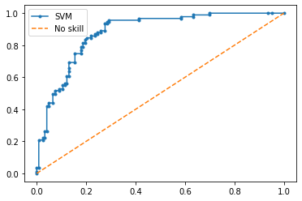

```python
fpr, tpr, thresholds = roc_curve(y_true=OJy_test,y_score =score, pos_label = clf.classes_[1])
plt.plot(fpr, tpr, marker='.', label='SVM')
plt.plot(tpr, tpr, linestyle='--', label='No skill')
plt.legend()
plt.show()
```

```python
roc_auc_score(OJy_test, score)
```

```
0.8813990887161619
```

# SVMs for regression

```python
Carseats=pd.read_csv('Carseats.csv',index_col=0)
Carseats.head()
```

|  | Sales | CompPrice | Income | Advertising | Population | Price | ShelveLoc | Age | Education | Urban | US |
| --- | --- | --- | --- | --- | --- | --- | --- | --- | --- | --- | --- |
| 1 | 9.50 | 138 | 73 | 11 | 276 | 120 | Bad | 42 | 17 | Yes | Yes |
| 2 | 11.22 | 111 | 48 | 16 | 260 | 83 | Good | 65 | 10 | Yes | Yes |
| 3 | 10.06 | 113 | 35 | 10 | 269 | 80 | Medium | 59 | 12 | Yes | Yes |
| 4 | 7.40 | 117 | 100 | 4 | 466 | 97 | Medium | 55 | 14 | Yes | Yes |
| 5 | 4.15 | 141 | 64 | 3 | 340 | 128 | Bad | 38 | 13 | Yes | No |

Again we would liket to transform the categorical to numerical ones.

```python
Carseats = pd.get_dummies(Carseats)
```

```python
X=Carseats.drop('Sales', axis=1)
y=Carseats.Sales
X= ss.fit_transform(X)
```

```python
X_train,X_test,y_train,y_test = train_test_split(X,y, test_size=0.2,random_state =30)
```

Now we can use the SVR to do the regression.

```python
clf = svm.SVR()
clf.fit(X_train,y_train)
MSE(clf.predict(X_test),y_test)
```

```
1.3693785807500622
```

```python
clf = svm.SVR(C=5)
clf.fit(X_train,y_train)
MSE(clf.predict(X_test),y_test)
```

```
1.140515209166118
```

```python
clf = svm.SVR(C=10,kernel="poly",degree = 2)
clf.fit(X_train,y_train)
MSE(clf.predict(X_test),y_test)
```

```
1.2992299729255605
```

```python
clf = svm.SVR(C=0.1,kernel="linear")
clf.fit(X_train,y_train)
MSE(clf.predict(X_test),y_test)
```

```
1.1375139247911927
```